# How To Win the Presidency?

Depeng Kong

September 11, 2020

Suppose one day you get to work for a billionare who became very motivated in politics because one of his business competitors with limited political knowledge, Donald J. Trump, had won the 2016 Presidency election.

You are then asked to provide an strategy that will potentially increase his chance of winning a future Presidency compaign. With nothing but historical and survey data, the exploratory journey to unfold as you in searching for a clue…

### Problem 0: Knowing What is At Hand.

Understanding the data is always the first step of any analysis. Since the boss wants to verify for himself that a businessman winning presidency isn’t just a coincidence, it is therefore worth the effort to start at recent pilots gathered beween 2016 and 2020.

```
[1] "Total response entries: 69889, total surveyed unique variables: 3426. "
```

It soon became obvious that in pilot surveys, many people tend to answer questions not serious/honest enough, or the responder might not even be a registered voter. For any of the above reasons, those participated dishonestly or not eligable would be excluded from this analysis so that it can be as persuasive to the boss as possible, it is first and foremost necessary to remove distrating inputs.

For the time series data, since it consists of data no later than 2016, and honesty was not a question on the list, we will just exclude those not eligible to vote.

```
[1] "Average percentage of invalid entries removed: 12.83%."
```

### Problem 1: Knowing the Most Important Problem Nationwide.

It is common sense that to get more votes, the candidate shall address enough problem solving skills to the American people that he can solve the most important problem on their lists. Thus it became clear that the first question that goes on the report is the most important one.

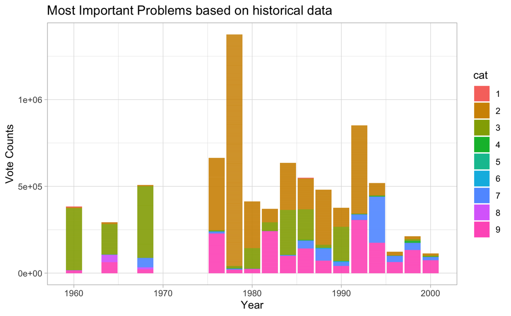

| values | ind |
| --- | --- |
| 0 | 00. None; 'there were no issues;' 'there was no campaign |
| 1 | 01. AGRICULTURAL |
| 2 | 02. ECONOMICS; BUSINESS; CONSUMER ISSUES |
| 3 | 03. FOREIGN AFFAIRS AND NATIONAL DEFENSE |
| 4 | 04. GOVERNMENT FUNCTIONING |
| 5 | 05. LABOR ISSUES |
| 6 | 06. NATURAL RESOURCES |
| 7 | 07. PUBLIC ORDER |
| 8 | 08. RACIAL PROBLEMS |
| 9 | 09. SOCIAL WELFARE |

[output cut: 3 more lines]

As can be observed, before 1970, the dominant problem existing in the U.S. are foreign affair issues, but has switched to mainly economics, business and consumer issues in the 1970s as economy grows vastly in that period. Meanwhile, social werfare has increased its count of shares and has became the most important problems in existance since late 1990s.

To conclude, there seems like a trend that underlying social issues is the most important problem that a President candidate should try to solve. To validate the guess, we shall look at some more recent data.

| value | n |
| --- | --- |
| trump | 311 |
| donald | 196 |
| democrats | 182 |
| immigration | 177 |
| illegal | 155 |
| climate | 147 |
| change | 116 |
| people | 113 |
| country | 109 |
| president | 107 |

[output cut: 990 more lines]

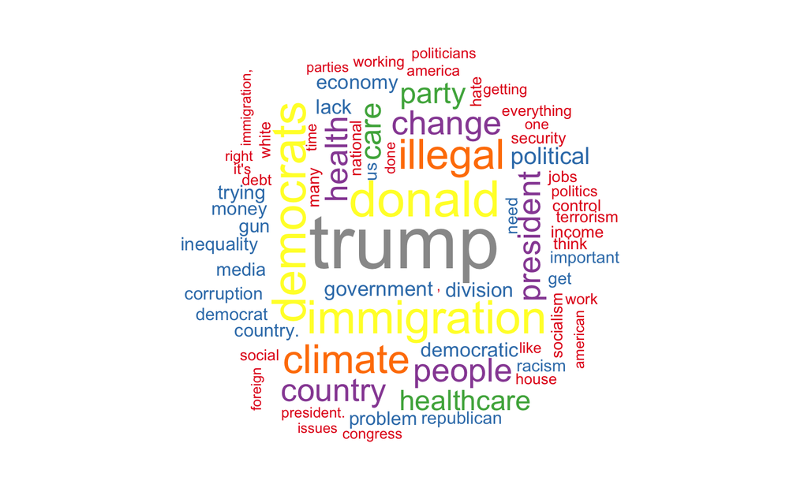

What’s shown above is a wordcloud generated from text entries from the 2019 pilot surbey. It shows that in 2019 President Trump and his addressed issues are what being considered “the most important problems in this country”. To solve these problems, we must know people’s opinions about how he’s doing his job so far.

### Problem 2: Knowing People’s Thoughts for the Current President As Well As Their Needs.

*Time Series Data*: First let’s examine how approved Presidents generally get historically.

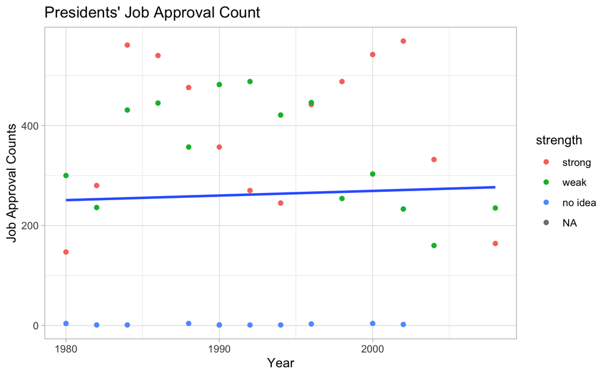

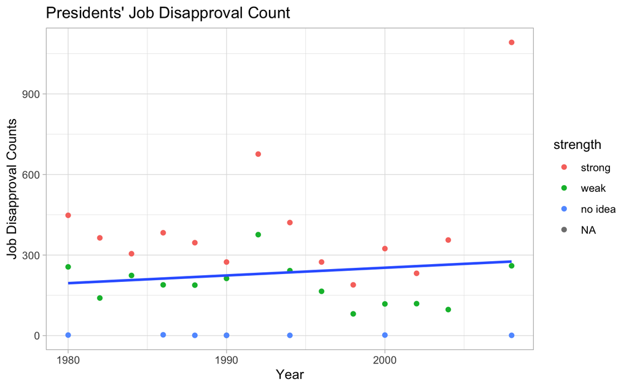

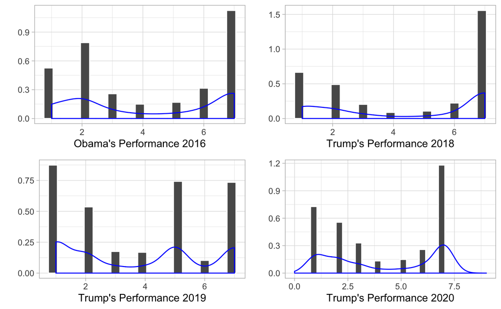

As can be observed from above plots, towards an end of a Presidency period, both Obama and Trump received much more disapproval votes from participants.

Also, although Trump had limited experience in Politics, which is probabily why he wasn’t quite supported at the beginning, he did prove that people do see and appreciate his efforts of hard work, which was reflected in the plot of 2019. Therefore, the billionare boss might also get a shot in doing a great job.

### Problem 3: Piecing Information Together.

First we need to find out which of the two aspects does most people disapprove the President about.

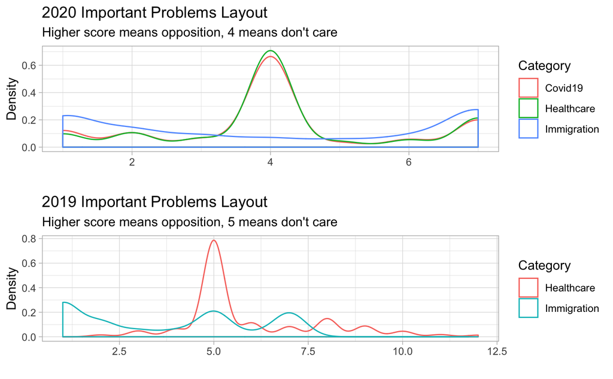

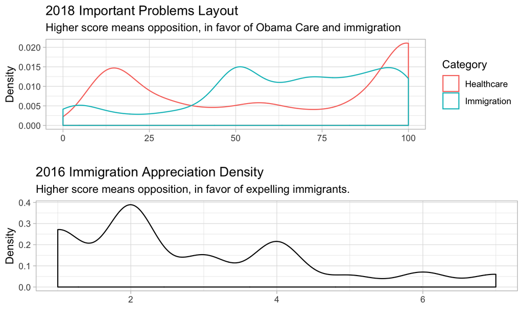

In 2016 when Obama was still the President, healthcare was not a big concern, thus were not included in the pilot survey. As Trump repeals the program, in 2018, 2019 and 2020 there are more people opposing the decision than favors it. As for immigration problems, we can see that in most years, people tend to favor foreign workers in the United States than to make them felons and expel to their home countries, because more people liked Obama’s attitute towards immigrants in 2016, and more people opposed Trump’s take in 2018.

In 2019, since Trump really put an effort in his job, many people approved his work and supported his take on immigration. But for the year 2020, because of the pandemic, more people opposed his decision on immigration and health care. The overall shape for 2020 however, is very polarized. One interesting findings in this part is that the curve for *Covid19* approval is almost the same as the one for *Healthcare*. It is not surprising since they are closely related, but a rater interesting social phenomenon to include in the surveys.

Based on the above analysis, it seems like although immigration is a very debatable topic, many people oppose Trump’s idea of keeping them out of this country. Healthcare however, does not seem to be an imminant problem for this country. Thus making you wonder, is there any other political forces that might affect the winning of a Presidency?

### Problem 4: Other Political Forces

In a Presidencial compaign, the one problem candidates must solve is how to take down their opponents, and one angle of approach fair and square is to make your fame better than theirs – that is to let people know you better than your opponents; and to examine the effect of this advocacy, we can examine some past data.

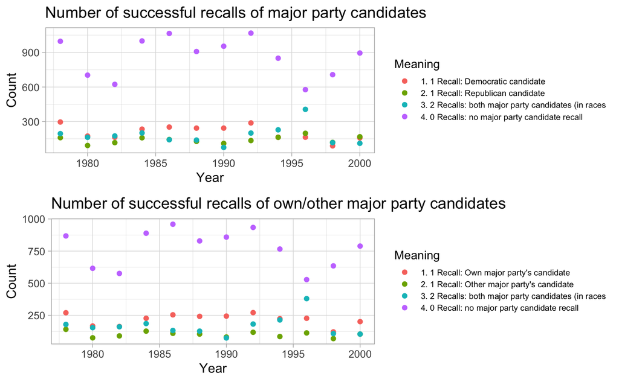

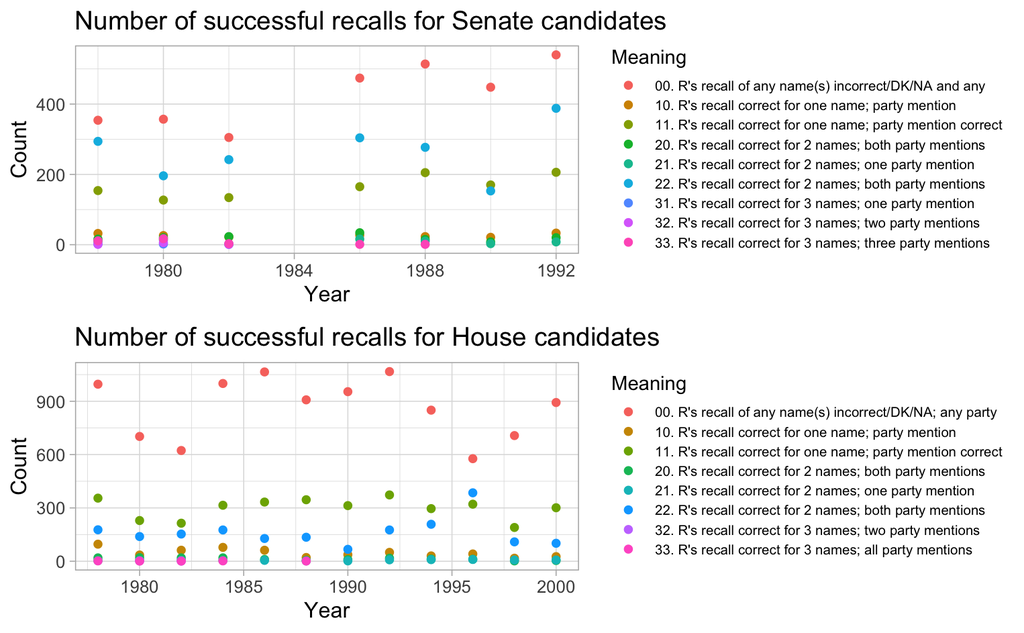

### To Conclude

*End of presentation*